# Pod 3 - R Notebook and Resources

Audrey Keleman

11/07/2023

# R Notebook Overview / Review

- Header
  - Specify output or “knit to..” (pdf, html, doc, ppt slides)
  - Floating table of contents specified in this example
- Chunks
  - Click green button or can type in (watch out for counting ` marks)
  - {r DESCRIPTION, arguments for this chunk}
  - include=FALSE if don’t want to include in the output
  - message = FALSE, warning = FALSE if you don’t want messages or warnings to appear in output
  - echo = FALSE if you don’t want the CODE in the chunk to appear in output, but you want any tables / figures/ output that results from the code to appear in the output (= TRUE if you want the code to appear with the output that results from it)
  - eval = FALSE if you don’t want the chunk to run at all when knitting (want it to be ignored)
  - can specify by each chunk, and also can set specifications that apply to whole Rmd file (see example - 1st R code chunk in this file; message and warnings set to FALSE)
- Outside chucks
  - Text formatting outside of code chunks
  - *italics*
  - **bold**
  - “-” or "*" for bulleted list; indent and “+” for sub-bullets
  - tab and 1. numbers for numbered list
  - extra spaces at end of a line to make a line break
  - “#” signs for organization of headers and table of contents
- There is an R cheat sheet for R Markdown and plenty of other fancy things online

Here, I find it helpful to describe the project I’m working on (brief background, aims, hypotheses); then describe dataset and sort of talk through each section through these sections with code and output to illustrate with the data.

# Miscellaneous Code to Share

Code that has been helpful for me in ReproRehab so far!

**The data content of these is not statistically sound/content is not meaningful, just giving examples!**

## Tables - gtsummary

### Demographics table by group

| **Characteristic** | **N** | **No Operation**, N = 94<sup>1</sup> | **Operation**, N = 11<sup>1</sup> | **p-value**<sup>2</sup> |
| --- | --- | --- | --- | --- |
| Age | 105 | 74 (7) | 68 (3) | <0.001 |
| Sex | 105 |  |  | >0.99 |
| Male |  | 82 (87%) | 10 (91%) |  |
| Female |  | 12 (13%) | 1 (9.1%) |  |
| PCS, Start | 98 | 9 (12) | 12 (11) | 0.51 |
| Grip Strength, Proportion | 92 | 0.47 (0.19) | 0.60 (0.24) | 0.17 |
| Times Outside Home | 94 | 5.67 (2.20) | 7.50 (2.73) | 0.10 |
| Distance Walked, km | 92 | 3.18 (2.64) | 5.64 (5.43) | 0.24 |
| Quick-DASH, 3 months | 82 | 33 (22) | 29 (32) | 0.72 |
| Quick-DASH, 12 months | 84 | 20 (17) | 11 (19) | 0.21 |
| VAS for Pain, 3 months | 94 | 23 (20) | 18 (20) | 0.53 |
| VAS for Pain, 12 months | 84 | 15 (18) | 12 (23) | 0.73 |

<sup>1</sup> Mean (SD); n (%)  
<sup>2</sup> Welch Two Sample t-test; Pearson’s Chi-squared test

### Regression tables

**The content of these (as with everything else here) is not statistically sound/content is not meaningful, just giving examples!**

DV = VAS, at 12 months

|  | vas12m |  |  |
| --- | --- | --- | --- |
| Predictors | Estimates | CI | p |
| (Intercept) | 15.99 | -34.41 – 66.38 | 0.529 |
| age | 0.14 | -0.51 – 0.78 | 0.677 |
| sex [Female] | 3.47 | -7.15 – 14.10 | 0.516 |
| pcs start | 0.09 | -0.23 – 0.42 | 0.568 |
| operativetreatment [Operation] | 5.27 | -7.48 – 18.02 | 0.412 |
| grip strength proportion | -25.16 | -44.86 – -5.45 | **0.013** |
| times outside from home | 0.03 | -1.95 – 2.00 | 0.979 |
| distance per week | -0.98 | -2.40 – 0.43 | 0.169 |
| Observations | 73 |  |  |
| R<sup>2</sup> / R<sup>2</sup> adjusted | 0.155 / 0.064 |  |  |
| AIC | 620.688 |  |  |

DV = VAS, at 12 months

|  | Grip Strength (Proportion) |  |  | Times Outside the Home |  |  | Distance Walked Per Week |  |  |
| --- | --- | --- | --- | --- | --- | --- | --- | --- | --- |
| Predictors | Estimates | CI | p | Estimates | CI | p | Estimates | CI | p |
| (Intercept) | 3.83 | -40.45 – 48.10 | 0.864 | 5.99 | -43.80 – 55.78 | 0.811 | 21.47 | -27.79 – 70.73 | 0.388 |
| age | 0.28 | -0.32 – 0.89 | 0.358 | 0.12 | -0.51 – 0.75 | 0.709 | -0.07 | -0.71 – 0.57 | 0.828 |
| sex [Female] | 7.07 | -3.48 – 17.61 | 0.186 | 6.00 | -5.17 – 17.17 | 0.287 | 3.05 | -7.76 – 13.85 | 0.575 |
| pcs start | 0.16 | -0.17 – 0.49 | 0.347 | 0.09 | -0.26 – 0.44 | 0.616 | 0.04 | -0.29 – 0.37 | 0.818 |
| operativetreatment [Operation] | 3.61 | -9.41 – 16.62 | 0.582 | -0.18 | -13.74 – 13.38 | 0.979 | 2.23 | -10.44 – 14.90 | 0.727 |
| grip strength proportion | -29.47 | -49.27 – -9.67 | **0.004** |  |  |  |  |  |  |
| times outside from home |  |  |  | -0.53 | -2.53 – 1.46 | 0.596 |  |  |  |
| distance per week |  |  |  |  |  |  | -1.42 | -2.81 – -0.04 | **0.045** |
| Observations | 74 |  |  | 75 |  |  | 74 |  |  |
| R<sup>2</sup> / R<sup>2</sup> adjusted | 0.138 / 0.075 |  |  | 0.030 / -0.040 |  |  | 0.068 / -0.000 |  |  |
| AIC | 633.398 |  |  | 649.639 |  |  | 631.203 |  |  |

## Correlation plot

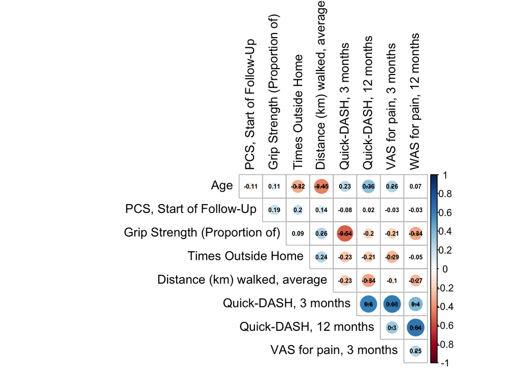

## Matching two data frames by nearest date and participant ID

This code creates a function (called MatchbyNearestDate) that takes two data frames (df1 and df2), filters them based on common IDs, finds the nearest date matches within each group (each common ID for each data frame- date in df2 closest to that in df1), and then merges the matched rows into a single data frame, which is returned as the output.